# Cyclistic Bike Share

DR

2024-06-21

## Cyclistic Bike Share

### Business task

Design marketing strategies aimed at converting casual riders into annual members.

### Problem question

How do annual members and casual riders use Cyclistic bikes differently?

### Problem statement

Analyzing the Cyclistic historical bike trip to identify trends between annual members and casual riders.

### Prepare

- Data is stored in `raw-data` folder.
- The data source has been made public under this [license](https://divvybikes.com/data-license-agreement).
- The following datasets have been used for analysis purposes:
  1. `Divvy_Trips_2019_Q1`.
  2. `Divvy_Trips_2020_Q1`.

| Data Type | Divvy_Trips_2019_Q1 | Divvy_Trips_2020_Q1 |
| --- | --- | --- |
| Character | `from_station_name` | `ride_id` |
|  | `to_station_name` | `rideable_type` |
|  | `usertype` | `start_station_name` |
|  | `gender` | `end_station_name` |
|  |  | `member_casual` |
| Double-precision | `trip_id` | `start_station_id` |
|  | `bikeid` | `end_station_id` |
|  | `from_station_id` | `start_lat` |
|  | `to_station_id` | `start_lng` |
|  | `birthyear` | `end_lat` |
| Numeric | `tripduration` | `end_lng` |
| Datetime | `start_time` | `started_at` |
|  | `end_time` | `ended_at` |

### Process

- Data processing has been done using R.
- Column names of `Divvy_Trips_2019_Q1` have been renamed to be consistent with column names of `Divvy_Trips_2020_Q1` as followings:
  - `trip_id` becomes `ride_id`
  - `bide_id` becomes `rideable_type`
  - `start_time` becomes `started_at`
  - `end_time` becomes `ended_at`
  - `from_station_name` becomes `start_station_name`
  - `to_station_name` becomes `end_station_name`
  - `from_station_id` becomes `start_station_id`
  - `to_station_id` becomes `end_station_id`
  - `usertype` becomes `member_casual`
- Converting `ride_id` and `rideable_type` in `Divvy_2019_Q1` to character data type so they can be compatible with data in `Divvy_2020_Q1`.
- Combining `Divvy_Trips_2019_Q1` and `Divvy_Trips_2020_Q1` into a single dataframe, named `Divvy_Trips_cleaned` which is stored in `cleaned-data` folder.
- `Divvy_Trips_cleaned` consists of the following columns and data types, respectively:
  - character: `ride_id`, `rideable_type`, `start_station_name`, `end_station_name`, `member_casual`
  - numerics: `start_station_id`, `end_station_id`
  - datetime: `started_at`, `ended_at`
- Reassigning the values of `member_casual`.
- Adding columns that list the date, month, day, and year of each ride.
- Adding a `ride_length` calculation to the dataframe by using the formula: `ride_length = ended_at - started_at`
- Removing bad data from the dataframe. Bad data contains “HQ QR” in `start_station_name`.
- The final dataframe named `Divvy_Trips_Final` has been stored in `cleaned-data` folder. This final dataframe has been prepared for analysis.

### Supporting visualizations and key findings

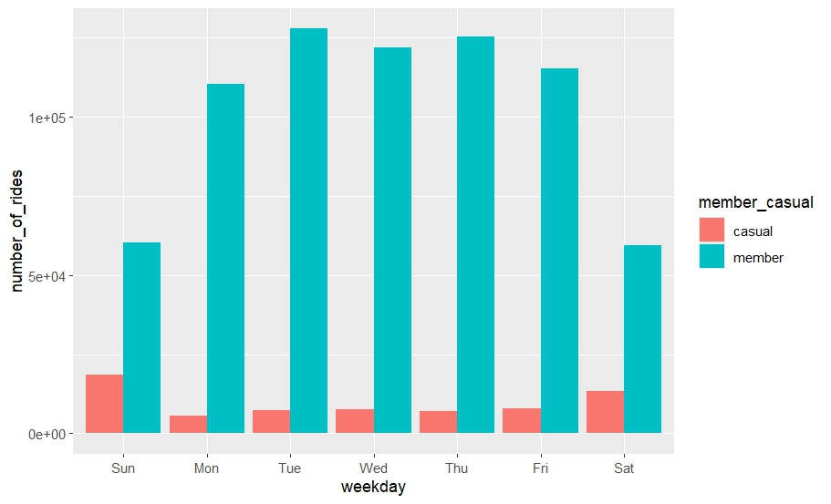

Number of riders by rider type.

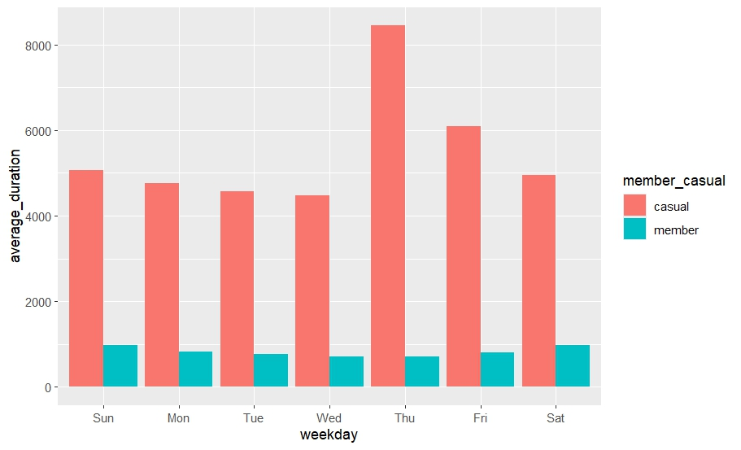